# Merab Gomez Final Project

Merab Gomez

3/13/2022

## Overview

This is the RMarkdown file for my final project. As a reminder, my final project is based on a paper I had to write for the PSYC 211 Statistics course. The paper was based on a study conducted in my lab. This study examined the effectiveness of a 7-day happiness intervention in which participants used a mobile gaming application to play mindset conditioning games called TAPPIT.I looked at how mindfulness levels changed across the 7 timepoints of the intervention.

In this document, I will be running/plotting:

- demographics
- descriptive statistics
- a repeated measures ANOVA
- a post-hoc Bonferroni test
- results in a box plot

More importantly, I will be detailing the different changes I made to my code that improved my original workflow’s **efficiency**, **fidelity** and **reproduciblility**.

## Step 1: Installing Packages

To begin, these are the necessary packages that must be installed and called through the library function.

```r
library(rstatix)
library(tidyr)
library(ggplot2)
library(dplyr)
library(ggpubr)
```

## Step 2: Data Import and Data Preparation

### Importing Dataset

Now, the data must be read in the data file. It is in a csv file called TAPPIT_Final_Dataset.csv and has already been de-indentified.

```r
TAPPIT_Final_Dataset <- read.csv("TAPPIT_Final_Dataset.csv")
```

**Side Note:** Lately, I’ve been getting errors with R Markdown saying it “could not find function read_csv”. I’ve tried trouble shooting this several times and sometimes it works and sometimes it doesn’t. To avoid this issue preventing me from completing this assignment and to play it safe, I’ve used the read.csv function instead.

### Removing Control Group Rows

As it stands, the TAPPIT_Final_Dataset that has been imported includes data from all participants in both the Experimental ans Control conditions.

For the purpose of my project, I wanted to only focus on participants in the **Experimental group**. These were participants who had played the TAPPIT games using images that depicted happy experiences. The condition.x column depicts which individuals were in each group where 0 = Control and 1 = Experimental.

Below you can see that I used the subset function to create a new data frame called Experimental_Group_Data where all participants who had a 0 in the condition column were excluded.

```r
Experimental_Group_Data <- subset(TAPPIT_Final_Dataset, Condition.x != "0")
```

This is an improvement in automation because in my original steps, I removed rows individually using Excel.This reduces the time spent on data preparation and reduces risk of human error.

## Step 3: Participant Demographics

As I mentioned in my workflow critique paper, I did not run any of the demographic information of my sample within R. Instead, I ran this information in Excel.As you know, this is problematic because it can be confusing working with multiple statistical platforms. Additionally, any future collaborators would not be able to easily view and access the demographic information by simply looking at my R code.

Below is the new code I created to include the demographic information and in doing so, I have completely converted my project to be fully in R Studio.

Using what I learned in class, I was also able to figure out how to not only get the count information for each of these variables but also get the percentages. This is very useful because I no longer have to worry about calculating these values by hand.

### Age

Here is my code for getting the mean and standard deviation of Age:

```r
mean(Experimental_Group_Data$Age)
```

```
## [1] 21.31481
```

```r
sd(Experimental_Group_Data$Age)
```

```
## [1] 2.568489
```

### Race and Ethinicity

Here is the code I used for racial and ethnic breakdown of my sample:

```r
Experimental_Group_Data %>%
  group_by(Ethnicity) %>%
  summarise(cnt = n()) %>%
  mutate(freq = formattable::percent(cnt / sum(cnt))) %>%
  arrange(desc(freq))
```

```
## # A tibble: 5 x 3
##   Ethnicity   cnt freq
##       <int> <int> <formttbl>
## 1         1    23 42.59%
## 2         2    22 40.74%
## 3         3     5 9.26%
## 4         6     3 5.56%
## 5         4     1 1.85%
```

The output may not make sense here because the groups are represented numerically, however, the new codebook that I’ve created breaks these groups down.

This is what each value represents: 1 = Asian American 2 = Latino American 3 = White 4 = Black 5 = Pacific Islander/Hawaiian 6 = Other

I’ve uploaded the new codebook to the GitHub repository for my final project in case you might want to verify.

### Gender

Here is the code I used for the breakdown of my sample by gender:

```r
Experimental_Group_Data %>%
  group_by(Gender) %>%
  summarise(cnt = n()) %>%
  mutate(freq = formattable::percent(cnt / sum(cnt))) %>%
  arrange(desc(freq))
```

```
## # A tibble: 2 x 3
##   Gender   cnt freq
##    <int> <int> <formttbl>
## 1      2    39 72.22%
## 2      1    15 27.78%
```

Similar to the Race/Ethnicity variable, the values represented in the Gender column are numerically represented.

Using the codebook I’ve created, we can see what each value represents: 1 = Male 2 = Female

### Creating a Function for Count and Percentage Breakdowns

Because I found this first code to be very useful in calculating counts and percentages of variable columns in my data, I thought it would be good to make this a function.

Below is the code for the function I created called demo_breakdown that I used to find the counts and percentages of the variables Education and Major.

```r
demo_breakdown <- function(data_file, column_name){ data_file %>%
  group_by({{column_name}}) %>%
  summarise(cnt = n()) %>%
  mutate(freq = formattable::percent(cnt / sum(cnt))) %>%
  arrange(desc(freq))}
```

### Using new Function

Here is the code where I simply use the function and input the arguments I want to focus on in order to get the demographic information I need.

```r
demo_breakdown(Experimental_Group_Data, Education)
```

```
## # A tibble: 3 x 3
##   Education   cnt freq
##       <int> <int> <formttbl>
## 1         3    31 57.41%
## 2         4    19 35.19%
## 3         2     4 7.41%
```

```r
demo_breakdown(Experimental_Group_Data, Major)
```

```
## # A tibble: 21 x 3
##    Major                                   cnt freq
##    <chr>                                 <int> <formttbl>
##  1 Psychology                               27 50.00%
##  2 psychology                                4 7.41%
##  3 business                                  3 5.56%
##  4 Business                                  2 3.70%
##  5 Business Administration                   2 3.70%
##  6 Business Administration, Management       1 1.85%
##  7 Business Economics                        1 1.85%
##  8 Business Finance                          1 1.85%
##  9 CNAS undeclared, working towards Econ     1 1.85%
## 10 econ admin                                1 1.85%
## # ... with 11 more rows
```

Although Education and Major are not necessarily relevant to the study, I now have code that will help me automate the process of examining the demographic information of my sample.Prior to this class I did not know that it was possible to create our own functions, so this is definitely an improvement.

## Step 4: More Data Preparation and Descriptive Statistics

As was described prior, the intervention lasted 7 days. In the case of the analyses, I was only focused on 3 different time points in which data on Mindfulness levels was collected. These 3 time points were on Day 1, Day 3 and Day 7 of the intervention.

### Preping the Mindfulness Variable

Before looking and the basic descriptive statistics of Mindfulness levels at different time points, there are a few steps that need to be done.

I need to:  
1. Select columns of interest  
2. Relabel columns  
3. Reverse Score Mindfulness measure

### Selecting Columns of Interest

Using the code below, I have selected all 3 time points of interest and added them to a new data file.Separating this data is necessary because I will be transforming these columns but do not wish to permanently do so or to alter any other columns.

```r
df_Mindful_Timepoints <- dplyr::select(Experimental_Group_Data,ID,T1_Mindfulness,T3_Mindfulness,T7_Mindfulness)
```

### Relabelling Columns

Instead of calling these columns by their original names, it would make my results more interpretable if I renamed them to be Day 1, Day 3, and Day 7.

This was the original code I used to relabel my columns.

```r
names(df_Mindful_Timepoints)[names(df_Mindful_Timepoints) == "T1_Mindfulness"] <- "Day 1"
names(df_Mindful_Timepoints)[names(df_Mindful_Timepoints) == "T3_Mindfulness"] <- "Day 3"
names(df_Mindful_Timepoints)[names(df_Mindful_Timepoints) == "T7_Mindfulness"] <- "Day 7"
```

### Reverse Scoring Mindfulness

Now that the labeling is done. I have to reverse score the Mindfulness scores. This is because the original Mindfulness measure results in high scores indicating **less** mindfulness.

Although this step might not be absolutely necessary, intuitively, it would make more sense to reverse the scores to indicate that the higher the score the **more** mindful a participant is.

```r
df_Mindful_Timepoints$`Day 1` <- 5-df_Mindful_Timepoints$`Day 1`
df_Mindful_Timepoints$`Day 3` <- 5-df_Mindful_Timepoints$`Day 3`
df_Mindful_Timepoints$`Day 7` <- 5-df_Mindful_Timepoints$`Day 7`
```

### Implementing Across Function

As a requirement for this project, I needed to use one the automation functions listed (i.e., map, for loop, across and read_csv). It was difficult figuring out where I should incorporate this since most of my code is relatively simple.

I decided to use the across function to summarize the mindfulness means of all 3 time points all at once, as you can see in the code below.

```r
distributions <- df_Mindful_Timepoints %>% summarise(across(2:4, mean))
distributions
```

```
##      Day 1    Day 3 Day 7
## 1 2.292593 2.477778   3.6
```

I wouldn’t say this line of code was extremely useful in this case, but I know I should at least be familiar with the across function. I am almost certain there was probably a better way of implementing it in a more useful way but it did the job here.

### Looking at Distributions

This is my code for looking at the distributions using histograms of all 3 time points.

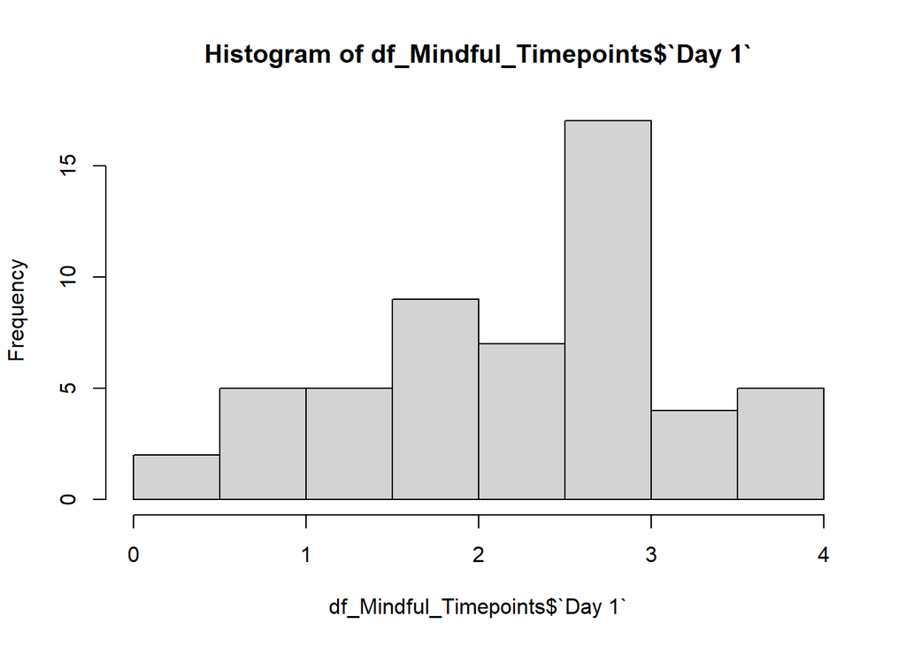

```r
hist(df_Mindful_Timepoints$`Day 1`)
```

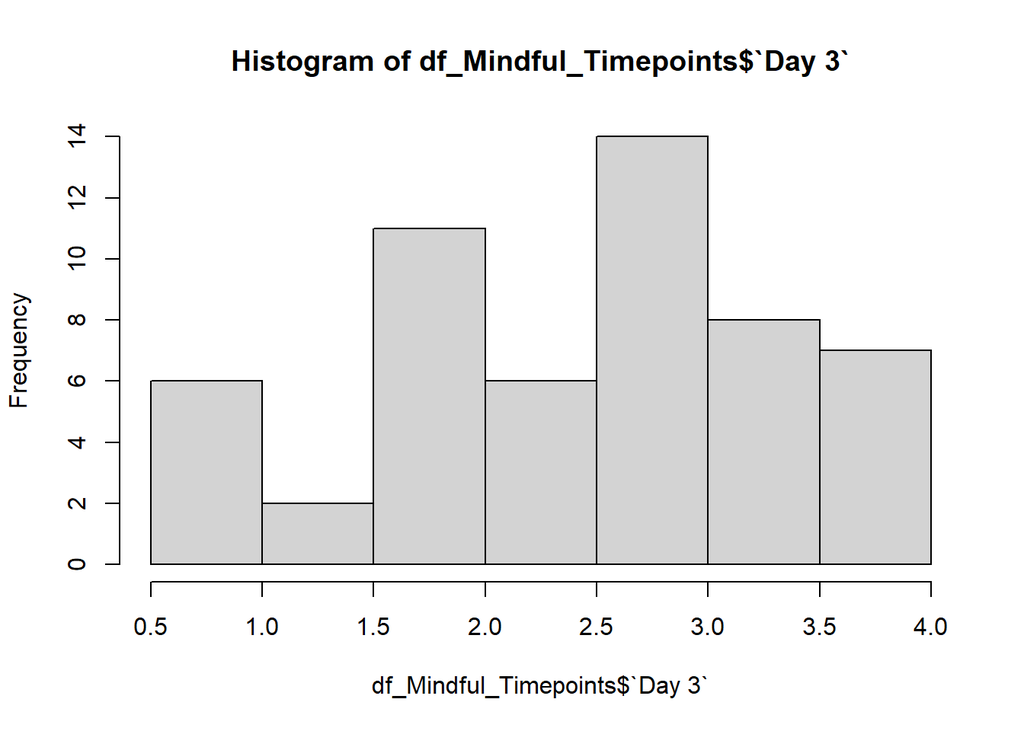

```r
hist(df_Mindful_Timepoints$`Day 3`)
```

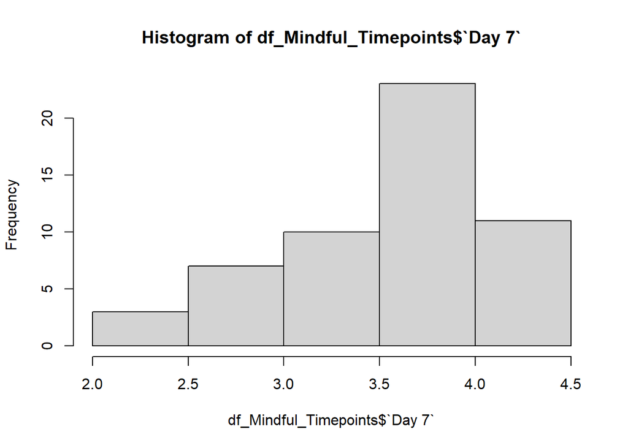

```r
hist(df_Mindful_Timepoints$`Day 7`)
```

I did not need to make these plots more visually appealing here because all I really wanted to make sure I was not violating normality assumptions. This quick visual glance at the descriptive data did not indicate any unusual or alarming distribution abnormalities. This would suggest that I can proceed to the next analyses.

## Step 5: Repeated Measures ANOVA

Before conducting the repeated measures ANOVA, I had to pivot my data over to long form. This is because each row must represent a participant and each column represent the time points across the intervention in order for the analysis to make sense.

### Pivoting Data

This is the code I used to reformat my code into long form.

```r
df_Pivot <- pivot_longer(df_Mindful_Timepoints,cols=c("Day 1","Day 3","Day 7"),names_to="Timepoints",values_to="Mindfulness")
```

### Repeated Measures ANOVA

Now I can run the repeated measures ANOVA to examine how Mindfulness levels changed for participants in the experimental group across the 3 different timepoints of interest.

```r
anova_model <- anova_test(data = df_Pivot, dv = Mindfulness, wid = ID, within = Timepoints)
get_anova_table(anova_model)
```

```
## ANOVA Table (type III tests)
##
##       Effect DFn DFd       F        p p<.05   ges
## 1 Timepoints   2 106 112.732 5.73e-27     * 0.341
```

The results of this analysis reveal a significant p-value with and effect size of 0.34.

### Summary of ANOVA Model

To gain a little more information about the ANOVA model, I simply re-ran the model name.

```r
anova_model
```

```
## ANOVA Table (type III tests)
##
## $ANOVA
##       Effect DFn DFd       F        p p<.05   ges
## 1 Timepoints   2 106 112.732 5.73e-27     * 0.341
##
## $`Mauchly's Test for Sphericity`
##       Effect     W     p p<.05
## 1 Timepoints 0.921 0.119
##
## $`Sphericity Corrections`
##       Effect   GGe      DF[GG]    p[GG] p[GG]<.05   HFe       DF[HF]    p[HF]
## 1 Timepoints 0.927 1.85, 98.27 3.47e-25         * 0.959 1.92, 101.68 5.67e-26
##   p[HF]<.05
## 1         *
```

Since the ANOVA model was significant, it is necessary to further investigate which specific time points differed from each other significantly.

## Step 6: Post-Hoc Bonferroni Test

A post-how Bonferroni test was conducted to check which timepoints were singnificantly different from each other.

```r
pwc <- df_Pivot %>%
  pairwise_t_test(
    Mindfulness ~ Timepoints, paired = TRUE,
    p.adjust.method = "bonferroni"
    )
pwc
```

```
## # A tibble: 3 x 10
##   .y.   group1 group2    n1    n2 statistic    df        p    p.adj p.adj.signif
## * <chr> <chr>  <chr>  <int> <int>     <dbl> <dbl>    <dbl>    <dbl> <chr>
## 1 Mind~ Day 1  Day 3     54    54     -1.75    53 8.6 e- 2 2.58e- 1 ns
## 2 Mind~ Day 1  Day 7     54    54    -14.2     53 1.09e-19 3.27e-19 ****
## 3 Mind~ Day 3  Day 7     54    54    -13.5     53 9.6 e-19 2.88e-18 ****
```

Results indicate that from Day 1 to Day 3 there was not a significant change in Mindfulness levels. However, all other comparisons were significantly different with Day 7 having significantly higher levels of Mindfulness compared to Day 1 and Day 3.

## Step 7: Plotting Data

To capture and visually represent the findings of my project, I created a box plot of Mindfulness levels across the 3 different timepoints of the intervention.

### Original Boxplot

This was the original code I used to create the box plots.

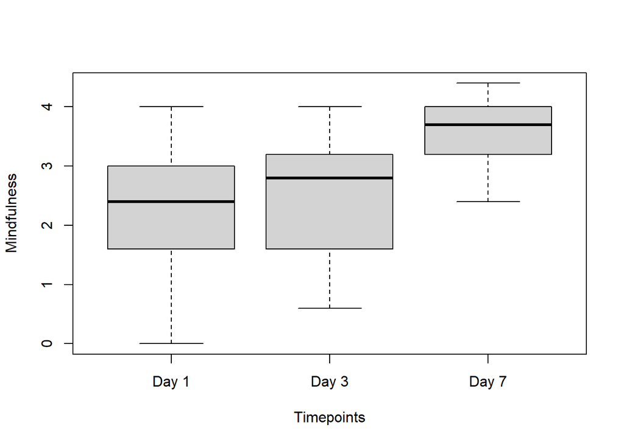

```r
boxplot(Mindfulness~Timepoints, data=df_Pivot)
```

### New Boxplot

As you can see, the box plot is pretty simple and rudimentary. It does not highlight what is important. Based on the tips and recommendations made in lecture, I created this new code to depict the same information.

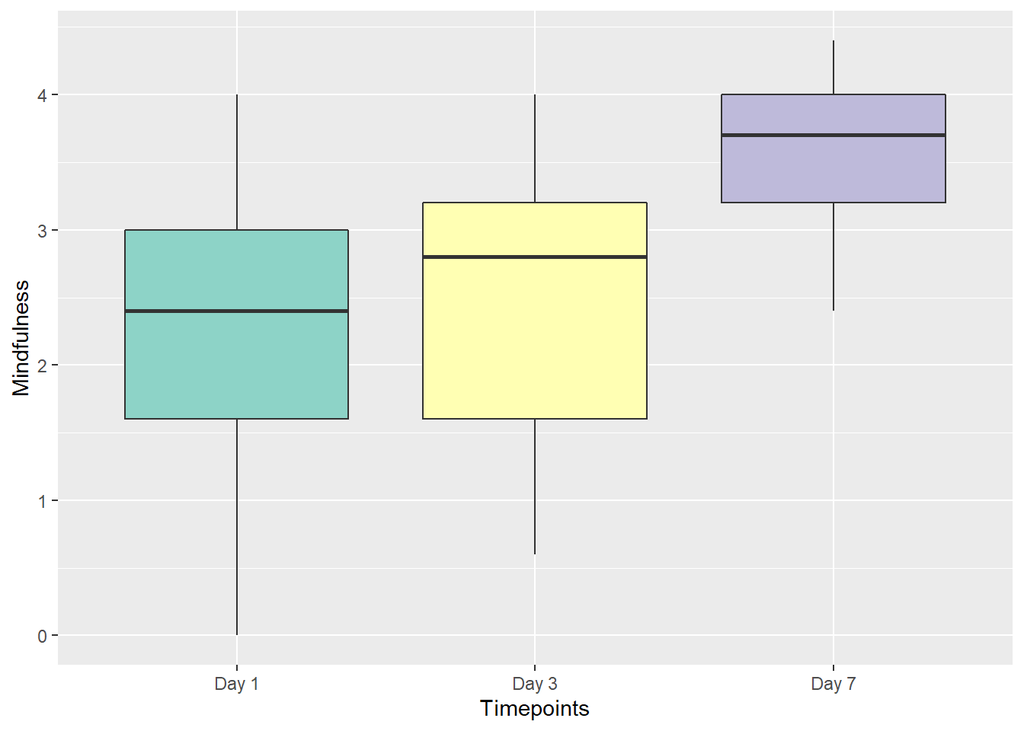

```r
ggplot(df_Pivot, aes(x=Timepoints, y=Mindfulness, fill=Timepoints)) +
    geom_boxplot(alpha=1) +
    theme(legend.position="none") +
    scale_fill_brewer(palette="Set3")
```

## Conclusion

Although I suspect there is much more I could do to make my code better, this was no doubt an improvement from what I began with. Now I have a completed R Markdown file containing all my code and was able to track my changes using Git Hub. By creating a repository, I can also share this information with other collaborators.

YAY FOR PROGRESS!!! :)